# 🏆 Simulando el Mundial FIFA 2026

# 13 =============================================================================

# 14 3. MERGE LIMPIO (Joins seguros)

# 15 =============================================================================

## 15.1 Integración de datos (Merge)

Unimos los 4 datasets en un único dataframe (`data_full`) usando `left_join()` sobre IDs numéricos. El resultado es una tabla de **104 partidos** con toda la información necesaria para el análisis:

- Equipos (nombre, grupo, código)
- Sede (estadio, ciudad, país)
- Rankings FIFA (puntos, posición)
- Variables derivadas (`rank_diff`, `points_diff`, `is_mexico`)

> `has_teams = TRUE` filtra los fixtures que aún tienen equipos placeholder (por ejemplo, “Winner UEFA Playoff D”), de los cuales hay algunos al inicio de torneo.

```r
rankings_clean <- rankings_raw %>%
  clean_names() %>%
  filter(!is.na(rk)) %>%
  rename(rank = rk, team_name = team, points = total_points,
         prev_points = previous_points, change = x) %>%
  select(rank, team_name, points) %>%
  mutate(team_name = case_when(
    team_name == "Korea Republic"               ~ "South Korea",
    team_name == "Türkiye"                      ~ "Turkey",
    team_name == "Congo DR"                     ~ "DR Congo",
    str_detect(team_name, "Cura")               ~ "Curaçao",
    str_detect(team_name, "Ivoire|ivoire|C.te") ~ "Côte d'Ivoire",
    TRUE ~ team_name
  ))

cat("Rankings limpios:", nrow(rankings_clean), "países\n\n")
```

```
## Rankings limpios: 210 países
```

```r
cat("🔍 Verificación equipos problemáticos:\n")
```

```
## 🔍 Verificación equipos problemáticos:
```

```r
rankings_clean %>%
  filter(team_name %in% c("USA","Côte d'Ivoire","IR Iran","Curaçao","South Korea","Turkey")) %>%
  print()
```

```
## # A tibble: 5 × 3
##    rank team_name     points
##   <dbl> <chr>          <dbl>
## 1    15 USA            1682.
## 2    20 IR Iran        1617.
## 3    22 South Korea    1599.
## 4    37 Côte d'Ivoire  1522.
## 5    81 Curaçao        1303.
```

```r
write_csv(rankings_clean, paste0(PATH_DATA, "fifa_rankings_clean.csv"))
print("Guardado: data/fifa_rankings_clean.csv ✅")
```

```
## [1] "Guardado: data/fifa_rankings_clean.csv ✅"
```

# 16 =============================================================================

# 17 4. MERGE PRINCIPAL

# 18 =============================================================================

```r
teams_clean <- teams %>%
  rename(team_id = 1, team_name = 2, team_code = 3,
         group = 4, is_placeholder = 5)

venues_clean <- venues %>%
  rename(city_id = 1, city_name = 2, country = 3,
         stadium = 4, region = 5, code = 6)

data_full <- matches %>%
  mutate(match_date = as.Date(kickoff_at)) %>%
  left_join(teams_clean %>% select(team_id, team_name, team_code, group, is_placeholder),
            by = c("home_team_id" = "team_id")) %>%
  rename(home_name = team_name, home_code = team_code,
         home_group = group, home_placeholder = is_placeholder) %>%
  left_join(teams_clean %>% select(team_id, team_name, team_code, group, is_placeholder),
            by = c("away_team_id" = "team_id")) %>%
  rename(away_name = team_name, away_code = team_code,
         away_group = group, away_placeholder = is_placeholder) %>%
  left_join(venues_clean %>% select(city_id, city_name, country, stadium),
            by = "city_id") %>%
  left_join(rankings_clean, by = c("home_name" = "team_name")) %>%
  rename(home_rank = rank, home_points = points) %>%
  left_join(rankings_clean, by = c("away_name" = "team_name")) %>%
  rename(away_rank = rank, away_points = points) %>%
  clean_names() %>%
  mutate(
    rank_diff   = coalesce(home_rank,   50L)   - coalesce(away_rank,   50L),
    points_diff = coalesce(home_points, 1400)  - coalesce(away_points, 1400),
    has_teams   = !home_placeholder & !away_placeholder,
    is_mexico   = country == "Mexico"
  )

cat("Total partidos :", nrow(data_full), "\n")
```

```
## Total partidos : 104
```

```r
cat("Con equipos reales :", sum(data_full$has_teams, na.rm = TRUE), "\n")
```

```
## Con equipos reales : 54
```

```r
cat("En sede México :", sum(data_full$is_mexico, na.rm = TRUE), "\n")
```

```
## En sede México : 13
```

```r
cat("\n🔍 Partidos con match_date NA:", sum(is.na(data_full$match_date)), "\n")
```

```
##
## 🔍 Partidos con match_date NA: 0
```

```r
data_full %>% filter(is.na(match_date)) %>% select(id, kickoff_at) %>% print()
```

```
## # A tibble: 0 × 2
## # ℹ 2 variables: id <dbl>, kickoff_at <dttm>
```

```r
write_csv(data_full, paste0(PATH_DATA, "mundial_2026_full.csv"), na = "")
write_rds(data_full, paste0(PATH_DATA, "mundial_2026_full.rds"))
print("Guardado: data/mundial_2026_full.csv | data/mundial_2026_full.rds ✅")
```

```
## [1] "Guardado: data/mundial_2026_full.csv | data/mundial_2026_full.rds ✅"
```

# 19 =============================================================================

# 20 5. VALIDAR COBERTURA DE RANKINGS…

# 21 =============================================================================

## 21.1 Cobertura de rankings

Verificamos que todos los equipos reales del torneo tengan un ranking FIFA asignado. La cobertura del 100% garantiza que el modelo de simulación no usará valores por defecto (`1400 pts`) para ningún equipo clasificado.

```r
teams_reales   <- teams_clean %>% filter(is_placeholder == FALSE) %>% pull(team_name)
con_ranking    <- teams_reales[teams_reales %in% rankings_clean$team_name]
sin_ranking    <- teams_reales[!teams_reales %in% rankings_clean$team_name]

cat("Equipos reales del Mundial :", length(teams_reales), "\n")
```

```
## Equipos reales del Mundial : 42
```

```r
cat("Con ranking FIFA :", length(con_ranking), "✅\n")
```

```
## Con ranking FIFA : 42 ✅
```

```r
cat("Sin ranking :", length(sin_ranking), "⚠\n\n")
```

```
## Sin ranking : 0 ⚠
```

```r
if (length(sin_ranking) > 0) {
  cat("Equipos a agregar en case_when del chunk 03:\n")
  print(sin_ranking)
} else {
  print("Cobertura 100% — todos los equipos tienen ranking")
}
```

```
## [1] "Cobertura 100% — todos los equipos tienen ranking"
```

# 22 =============================================================================

# 23 6. PREPARANDO SIMULACIÓN MONTE CARLO…

# 24 =============================================================================

## 24.1 Modelo de simulación

### 24.1.1 Supuestos del modelo

El modelo de predicción se basa en los siguientes supuestos:

1. **La fuerza de un equipo** está bien aproximada por sus puntos FIFA
2. **La probabilidad de victoria** sigue una función logística sobre la diferencia de puntos
3. **Los goles** siguen una distribución Poisson con media proporcional a la diferencia de fuerza
4. **Ventaja de sede** de México: +8% sobre la probabilidad base (ajustable)
5. **En eliminatorias**, los empates se resuelven por penales (probabilidad 50/50)

### 24.1.2 Limitaciones conocidas

- No considera lesiones, sanciones ni rendimiento reciente
- Los placeholders (clasificados por playoff) se excluyen de la simulación hasta que sean conocidos
- El boost de sede es un estimado; puede calibrarse con datos históricos de mundiales pasados

```r
sim_match <- function(points_home, points_away, home_boost = 0) {
  diff   <- (points_home - points_away) / 600 + home_boost
  p_home <- plogis(diff + 0.1)
  p_away <- plogis(-diff)
  p_draw <- 1 - p_home - p_away
  probs  <- pmax(c(p_home, p_draw, p_away), 0.05)
  probs  <- probs / sum(probs)
  sample(c("home", "draw", "away"), size = 1, prob = probs)
}

sim_group <- function(data_full, teams_ranked, mexico_boost = 0.08) {
  results <- list()
  grupos  <- data_full %>%
    filter(has_teams == TRUE, !is.na(home_group)) %>%
    pull(home_group) %>% unique()

  for (g in grupos) {
    group_matches <- data_full %>% filter(home_group == g, has_teams == TRUE)
    group_teams   <- unique(c(group_matches$home_name, group_matches$away_name))
    standings     <- tibble(team = group_teams, pts = 0, gf = 0, ga = 0, played = 0)

    for (i in seq_len(nrow(group_matches))) {
      h     <- group_matches$home_name[i]
      a     <- group_matches$away_name[i]
      h_pts <- teams_ranked$points[teams_ranked$team == h]
      a_pts <- teams_ranked$points[teams_ranked$team == a]
      h_pts <- ifelse(length(h_pts) == 0 || is.na(h_pts), 1400, h_pts)
      a_pts <- ifelse(length(a_pts) == 0 || is.na(a_pts), 1400, a_pts)
      boost  <- ifelse(group_matches$is_mexico[i], mexico_boost, 0)
      result <- sim_match(h_pts, a_pts, home_boost = boost)
      lh <- exp(0.3 + (h_pts - a_pts) / 2000)
      la <- exp(0.3 - (h_pts - a_pts) / 2000)
      gh <- rpois(1, pmin(lh, 5))
      ga <- rpois(1, pmin(la, 5))
      if (result == "home") {
        standings$pts[standings$team == h] <- standings$pts[standings$team == h] + 3
      } else if (result == "away") {
        standings$pts[standings$team == a] <- standings$pts[standings$team == a] + 3
      } else {
        standings$pts[standings$team == h] <- standings$pts[standings$team == h] + 1
        standings$pts[standings$team == a] <- standings$pts[standings$team == a] + 1
      }
      standings$gf[standings$team == h] <- standings$gf[standings$team == h] + gh
      standings$ga[standings$team == h] <- standings$ga[standings$team == h] + ga
      standings$gf[standings$team == a] <- standings$gf[standings$team == a] + ga
      standings$ga[standings$team == a] <- standings$ga[standings$team == a] + gh
      standings$played[standings$team == h] <- standings$played[standings$team == h] + 1
      standings$played[standings$team == a] <- standings$played[standings$team == a] + 1
    }
    standings  <- standings %>%
      mutate(gd = gf - ga, group = g) %>%
      arrange(desc(pts), desc(gd), desc(gf))
    results[[g]] <- standings
  }

  all_standings <- bind_rows(results)
  top2 <- all_standings %>%
    group_by(group) %>% slice_head(n = 2) %>%
    mutate(classified_as = ifelse(row_number() == 1, "1st", "2nd")) %>% ungroup()
  terceros <- all_standings %>%
    group_by(group) %>% slice(3) %>% ungroup() %>%
    arrange(desc(pts), desc(gd), desc(gf)) %>%
    slice_head(n = 8) %>% mutate(classified_as = "3rd")
  bind_rows(top2, terceros) %>% select(team, pts, gd, gf, group, classified_as)
}

sim_knockout <- function(teams_vec, teams_ranked) {
  winners <- c()
  for (i in seq(1, length(teams_vec), by = 2)) {
    h     <- teams_vec[i];  a <- teams_vec[i + 1]
    h_pts <- teams_ranked$points[teams_ranked$team == h]
    a_pts <- teams_ranked$points[teams_ranked$team == a]
    h_pts <- ifelse(length(h_pts) == 0 || is.na(h_pts), 1400, h_pts)
    a_pts <- ifelse(length(a_pts) == 0 || is.na(a_pts), 1400, a_pts)
    result <- sim_match(h_pts, a_pts)
    winner <- if (result == "home") h else if (result == "away") a else sample(c(h, a), 1)
    winners <- c(winners, winner)
  }
  winners
}

run_tournament <- function(data_full, teams_ranked, mexico_boost = 0.08) {
  clasificados <- sim_group(data_full, teams_ranked, mexico_boost)
  equipos_kn   <- clasificados$team
  while (length(equipos_kn) < 32) equipos_kn <- c(equipos_kn, sample(clasificados$team, 1))
  equipos_kn <- equipos_kn[1:32]
  r32    <- sim_knockout(equipos_kn, teams_ranked)
  r16    <- sim_knockout(r32,        teams_ranked)
  qf     <- sim_knockout(r16,        teams_ranked)
  sf     <- sim_knockout(qf,         teams_ranked)
  campeon <- sim_knockout(sf,        teams_ranked)
  list(champion = campeon, finalist = sf, semi = qf, quarter = r16)
}

print("Funciones de simulación cargadas (F1–F4) ✅")
```

```
## [1] "Funciones de simulación cargadas (F1–F4) ✅"
```

# 25 =============================================================================

# 26 7. EJECUTANDO SIMULACIÓN MONTE CARLO [10k]…

# 27 =============================================================================

```r
teams_ranked <- data_full %>%
  filter(has_teams == TRUE) %>%
  select(home_name, home_points) %>%
  rename(team = home_name, points = home_points) %>%
  bind_rows(
    data_full %>% filter(has_teams == TRUE) %>%
      select(away_name, away_points) %>%
      rename(team = away_name, points = away_points)
  ) %>%
  filter(!is.na(points)) %>%
  distinct(team, .keep_all = TRUE)

cat("Equipos en simulación:", nrow(teams_ranked), "\n\n")
```

```
## Equipos en simulación: 42
```

```r
set.seed(2026)
N_SIMS    <- 10000
champions <- character(N_SIMS)
finalists <- character(N_SIMS * 2)

cat("🔄 Corriendo", N_SIMS, "simulaciones...\n")
```

```
## 🔄 Corriendo 10000 simulaciones...
```

```r
start_time <- Sys.time()

for (i in seq_len(N_SIMS)) {
  result       <- run_tournament(data_full, teams_ranked)
  champions[i] <- result$champion
  finalists[((i - 1) * 2 + 1):(i * 2)] <- result$finalist
  if (i %% 2000 == 0) cat(" →", i, "completadas...\n")
}
```

```
##  → 2000 completadas...
##  → 4000 completadas...
##  → 6000 completadas...
##  → 8000 completadas...
##  → 10000 completadas...
```

```r
elapsed <- round(as.numeric(Sys.time() - start_time, units = "secs"), 1)
cat("Completado en", elapsed, "segundos ✅\n")
```

```
## Completado en 1065.2 segundos ✅
```

# 28 =============================================================================

# 29 8. RESULTADOS Y EXPORTACIÓN

# 30 =============================================================================

## 30.1 Resultados: Simulación Monte Carlo

Corrimos **10,000 torneos completos** con semilla `set.seed(2026)` para garantizar reproducibilidad. Los resultados reflejan las probabilidades estadísticas basadas exclusivamente en los rankings FIFA actuales y la estructura del torneo.

### 30.1.1 Observaciones clave

- **España, Argentina y Francia** concentran ~19% de las probabilidades de título, coherente con su dominio en los rankings FIFA
- **México** aparece en el puesto **#11 de campeón (3.63%)** y **#9 de llegar a la final (7.39%)**, beneficiado por el boost de sede local
- La distribución es relativamente plana (6.61% máximo), lo que refleja el nuevo formato de 48 equipos donde hay más variabilidad en el torneo

```r
prob_campeon <- table(champions) %>%
  as_tibble() %>%
  rename(team = champions, n_wins = n) %>%
  mutate(prob_title = round(n_wins / N_SIMS * 100, 2)) %>%
  arrange(desc(prob_title))

prob_final <- table(finalists) %>%
  as_tibble() %>%
  filter(finalists != "") %>%
  rename(team = finalists, n_final = n) %>%
  mutate(prob_final = round(n_final / N_SIMS * 100, 2)) %>%
  arrange(desc(prob_final))

cat("🏆 TOP 15 - PROBABILIDAD DE CAMPEÓN:\n")
```

```
## 🏆 TOP 15 - PROBABILIDAD DE CAMPEÓN:
```

```r
cat("══════════════════════════════════════\n")
```

```
## ══════════════════════════════════════
```

```r
prob_campeon %>% slice_head(n = 15) %>% print(n = 15)
```

```
## # A tibble: 15 × 3
##    team        n_wins prob_title
##    <chr>        <int>      <dbl>
##  1 Spain          661       6.61
##  2 Argentina      618       6.18
##  3 France         594       5.94
##  4 England        495       4.95
##  5 Germany        415       4.15
##  6 Brazil         414       4.14
##  7 Netherlands    404       4.04
##  8 Belgium        394       3.94
##  9 Morocco        393       3.93
## 10 Portugal       386       3.86
## 11 Mexico         363       3.63
## 12 Switzerland    317       3.17
## 13 Croatia        310       3.1
## 14 USA            303       3.03
## 15 Colombia       286       2.86
```

```r
cat("\n🥈 TOP 10 - PROBABILIDAD DE LLEGAR A LA FINAL:\n")
```

```
##
## 🥈 TOP 10 - PROBABILIDAD DE LLEGAR A LA FINAL:
```

```r
cat("══════════════════════════════════════════════\n")
```

```
## ══════════════════════════════════════════════
```

```r
prob_final %>% slice_head(n = 10) %>% print(n = 10)
```

```
## # A tibble: 10 × 3
##    team        n_final prob_final
##    <chr>         <int>      <dbl>
##  1 Spain          1111      11.1
##  2 Argentina      1080      10.8
##  3 France         1054      10.5
##  4 England         912       9.12
##  5 Brazil          811       8.11
##  6 Morocco         765       7.65
##  7 Germany         759       7.59
##  8 Netherlands     753       7.53
##  9 Mexico          739       7.39
## 10 Belgium         736       7.36
```

```r
cat("\n🇲🇽 MÉTRICAS MÉXICO:\n")
```

```
##
## 🇲🇽 MÉTRICAS MÉXICO:
```

```r
cat("══════════════════════\n")
```

```
## ══════════════════════
```

```r
mex_title <- prob_campeon %>% filter(team == "Mexico") %>% pull(prob_title)
mex_final <- prob_final   %>% filter(team == "Mexico") %>% pull(prob_final)
cat("Probabilidad campeón :", ifelse(length(mex_title) > 0, paste0(mex_title, "%"), "< 0.01%"), "\n")
```

```
## Probabilidad campeón : 3.63%
```

```r
cat("Probabilidad final   :", ifelse(length(mex_final) > 0, paste0(mex_final, "%"), "< 0.01%"), "\n")
```

```
## Probabilidad final   : 7.39%
```

```r
write_csv(prob_campeon, paste0(PATH_OUTPUT, "sim_prob_campeon.csv"))
write_csv(prob_final,   paste0(PATH_OUTPUT, "sim_prob_final.csv"))
print("Exportados: output/sim_prob_campeon.csv | output/sim_prob_final.csv ✅")
```

```
## [1] "Exportados: output/sim_prob_campeon.csv | output/sim_prob_final.csv ✅"
```

# 31 =============================================================================

# 32 09 - VISUALIZACIÓN: Probabilidades de Campeón

# 33 =============================================================================

## 33.1 Visualizaciones

Las gráficas se generan con `ggplot2` y se exportan en alta resolución (300 dpi) a `output/`. Están listas para incluirse en presentaciones, reportes o el README de GitHub.

[figure not shown]

```r
plot_campeon <- prob_campeon %>%
  slice_head(n = 15) %>%
  mutate(
    iso2 = tolower(countrycode(team, origin = 'country.name', destination = 'iso2c')),
    iso2 = ifelse(team == "England", "gb-eng", iso2)
  )
g_campeon <- ggplot(plot_campeon, aes(x = reorder(team, prob_title), y = prob_title)) +
  geom_segment(aes(xend = team, y = 0, yend = prob_title), color = "gray70", size = 1.2) +
  geom_flag(aes(y = prob_title + 0.2, image = iso2), size = 0.05) +
  geom_text(aes(y = prob_title + 0.8, label = paste0(prob_title, "%")),
            size = 4.5, fontface = "bold", color = "#F4D03F") +
  coord_flip() +
  scale_y_continuous(limits = c(0, max(plot_campeon$prob_title) + 1.5)) +
  labs(
    title    = "🏆 Probabilidad de ganar el Mundial 2026",
    subtitle = "Basado en 10,000 simulaciones de Monte Carlo con Rankings FIFA",
    x = "", y = "Probabilidad (%)",
    caption  = "Elaborado para Portafolio de Análisis de Datos"
  ) +
  theme_minimal(base_size = 14) +
  theme(
    plot.background  = element_rect(fill = "#1a1a2e", color = NA),
    panel.background = element_rect(fill = "#1a1a2e", color = NA),
    plot.title    = element_text(face = "bold", size = 18, margin = margin(b = 10), color = "white"),
    plot.subtitle = element_text(color = "gray60", size = 12, margin = margin(b = 20)),
    axis.text     = element_text(face = "bold", color = "#a0aec0", size = 12),
    panel.grid.major.y = element_blank(),
    panel.grid.minor.x = element_blank(),
    panel.grid.major.x = element_line(color = "#2d3748", linewidth = 0.3)
  )

print(g_campeon)
```

```r
ggsave(paste0(PATH_OUTPUT, "plot_campeon.png"), g_campeon, width = 10, height = 7, dpi = 300)
print("Gráfico de campeón guardado en output/plot_campeon.png ✅")
```

```
## [1] "Gráfico de campeón guardado en output/plot_campeon.png ✅"
```

# 34 =============================================================================

# 35 10 - Visualización: Distribución de Sedes (Enfoque México)…

# 36 =============================================================================

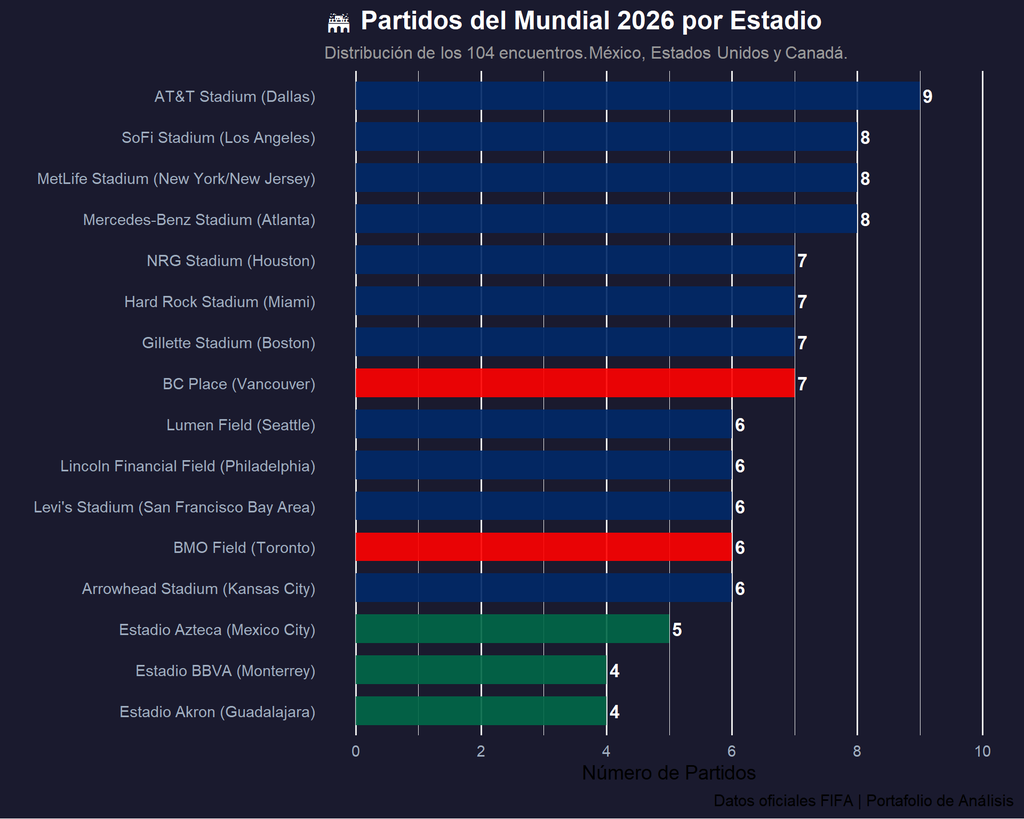

```r
plot_sedes <- data_full %>%
  count(stadium, city_name, country) %>%
  arrange(desc(n)) %>%
  mutate(
    sede_label = paste0(stadium, " (", city_name, ")"),
    color_pais = case_when(
      country == "Mexico" ~ "#006847",
      country == "USA"    ~ "#002868",
      country == "Canada" ~ "#FF0000",
      TRUE ~ "gray"
    )
  )

g_sedes <- ggplot(plot_sedes, aes(x = reorder(sede_label, n), y = n, fill = color_pais)) +
  geom_col(width = 0.7, alpha = 0.9) +
  geom_text(aes(label = n), hjust = -0.3, size = 4.5, fontface = "bold", color = "white") +
  coord_flip() +
  scale_fill_identity() +
  scale_y_continuous(limits = c(0, max(plot_sedes$n) + 1), breaks = seq(0, 10, by = 2)) +
  labs(
    title    = "🏟️ Partidos del Mundial 2026 por Estadio",
    subtitle = "Distribución de los 104 encuentros. México, Estados Unidos y Canadá.",
    x = "", y = "Número de Partidos",
    caption  = "Datos oficiales FIFA | Portafolio de Análisis"
  ) +
  theme_minimal(base_size = 14) +
  theme(
    plot.background  = element_rect(fill = "#1a1a2e", color = NA),
    panel.background = element_rect(fill = "#1a1a2e", color = NA),
    plot.title    = element_text(face = "bold", size = 18, color = "white"),
    plot.subtitle = element_markdown(size = 12, color = "gray60"),
    axis.text     = element_text(size = 11, color = "#a0aec0"),
    panel.grid.major.y = element_blank(),
    legend.position = "none"
  )

print(g_sedes)
```

```r
ggsave(paste0(PATH_OUTPUT, "plot_sedes.png"), g_sedes, width = 10, height = 8, dpi = 300)
print("✅ Gráfico de sedes guardado en output/plot_sedes.png")
```

```
## [1] "✅ Gráfico de sedes guardado en output/plot_sedes.png"
```

# 37 =============================================================================

# 38 11: CSV AUXILIARES PARA POWER BI

# 39 =============================================================================

```r
write_csv_utf8 <- function(x, path, ...) {
  tmp <- tempfile(fileext = ".csv")
  readr::write_csv(x, tmp, ...)
  raw <- readBin(tmp, what = "raw", n = file.info(tmp)$size)
  bom <- charToRaw("\ufeff")
  writeBin(c(bom, raw), path)
}

curiosidades <- tibble(
  categoria = c(
    "Países campeones","Finales más goleadoras","Goles promedio/edición",
    "Partidos más largos","Ediciones disputadas","Países participantes total",
    "Récord victorias consecutivas","Goles totales","% empates",
    "Victorias locales","Finales por penales","Remontadas épicas",
    "México en Mundiales","México títulos"
  ),
  valor = c(
    "8","1958 (9 goles)","2.8","120 min","22",
    "82 países","25 victorias (Brasil)","2,778","26%",
    "41%","5","12%","17/22","0"
  ),
  fuente = c(
    "Histórico","Suecia 1958","1930-2022","Prórrogas","1930-2022",
    "Histórico","1970","Histórico","Histórico","Histórico",
    "1994, 2006...","Estadística","Histórico","Histórico"
  )
)
write_csv_utf8(curiosidades, "../datasets/dim_curiosidades_mundial.csv", na = "")
cat("✅ dim_curiosidades_mundial.csv:", nrow(curiosidades), "filas\n")
```

```
## ✅ dim_curiosidades_mundial.csv: 14 filas
```

```r
hist_completo <- read_csv(
  "../datasets/FIFA World Cup 1930-2022 All Match Dataset.csv",
  show_col_types = FALSE
)

campeones_finales <- hist_completo %>%
  filter(`Stage Name` == "final") %>%
  mutate(
    campeon = case_when(
      `Home Team Win` == 1 ~ `Home Team Name`,
      `Away Team Win` == 1 ~ `Away Team Name`,
      TRUE ~ NA_character_
    ),
    campeon = case_when(campeon == "West Germany" ~ "Germany", TRUE ~ campeon)
  ) %>%
  pull(campeon) %>% discard(is.na)

campeones_completos       <- c(campeones_finales, "Uruguay")
dim_titulos_historicos    <- tibble(team = campeones_completos) %>%
  count(team, name = "titulos_historicos") %>%
  arrange(dplyr::desc(titulos_historicos))

write_csv_utf8(dim_titulos_historicos, "../datasets/dim_titulos_historicos.csv", na = "")
cat("✅ dim_titulos_historicos.csv:", nrow(dim_titulos_historicos), "equipos\n")
```

```
## ✅ dim_titulos_historicos.csv: 8 equipos
```

```r
print(dim_titulos_historicos)
```

```
## # A tibble: 8 × 2
##   team      titulos_historicos
##   <chr>                  <int>
## 1 Brazil                     5
## 2 Germany                    4
## 3 Italy                      4
## 4 Argentina                  3
## 5 France                     2
## 6 Uruguay                    2
## 7 England                    1
## 8 Spain                      1
```

```r
# ✅ FIX: objeto renombrado de dim_jugadores_top → dim_leyendas (consistente)
dim_leyendas <- tibble(
  jugador = c(
    "Miroslav Klose","Ronaldo","Gerd Müller","Just Fontaine","Lionel Messi",
    "Peter Shilton","Fabien Barthez","Hugo Lloris","Manuel Neuer","Iker Casillas"
  ),
  tipo    = c(rep("Goleador", 5), rep("Portero", 5)),
  record  = c(16, 15, 14, 13, 13, 10, 9, 8, 7, 7),
  pais    = c("Germany","Brazil","Germany","France","Argentina",
              "England","France","France","Germany","Spain"),
  mundiales = c(4, 3, 2, 1, 5, 3, 3, 3, 2, 3)
) %>%
  arrange(tipo, desc(record)) %>%
  mutate(promedio_por_mundial = round(record / mundiales, 1))

write_csv_utf8(dim_leyendas, "../datasets/dim_leyendas.csv", na = "")
cat("✅ dim_leyendas.csv:", nrow(dim_leyendas), "jugadores\n")
```

```
## ✅ dim_leyendas.csv: 10 jugadores
```

```r
print(dim_leyendas)
```

```
## # A tibble: 10 × 6
##    jugador        tipo     record pais      mundiales promedio_por_mundial
##    <chr>          <chr>     <dbl> <chr>         <dbl>                <dbl>
##  1 Miroslav Klose Goleador     16 Germany           4                  4
##  2 Ronaldo        Goleador     15 Brazil            3                  5
##  3 Gerd Müller    Goleador     14 Germany           2                  7
##  4 Just Fontaine  Goleador     13 France            1                 13
##  5 Lionel Messi   Goleador     13 Argentina         5                  2.6
##  6 Peter Shilton  Portero      10 England           3                  3.3
##  7 Fabien Barthez Portero       9 France            3                  3
##  8 Hugo Lloris    Portero       8 France            3                  2.7
##  9 Manuel Neuer   Portero       7 Germany           2                  3.5
## 10 Iker Casillas  Portero       7 Spain             3                  2.3
```

```r
partidos_largo <- bind_rows(
  hist_completo %>%
    transmute(fecha = lubridate::mdy(`Match Date`), team = `Home Team Name`, victoria = `Home Team Win`),
  hist_completo %>%
    transmute(fecha = lubridate::mdy(`Match Date`), team = `Away Team Name`, victoria = `Away Team Win`)
) %>%
  mutate(team = case_when(team == "West Germany" ~ "Germany", TRUE ~ team)) %>%
  arrange(team, fecha)

max_racha <- function(victorias) {
  if (all(victorias == 0)) return(0)
  r <- rle(victorias)
  max(r$lengths[r$values == 1], na.rm = TRUE)
}

dim_rachas_victorias <- partidos_largo %>%
  group_by(team) %>%
  summarise(
    partidos_totales        = n(),
    victorias_totales       = sum(victoria, na.rm = TRUE),
    record_victorias_consec = max_racha(victoria),
    .groups = "drop"
  ) %>%
  arrange(desc(record_victorias_consec))

write_csv_utf8(dim_rachas_victorias, "../datasets/dim_rachas_victorias.csv")
cat("✅ dim_rachas_victorias.csv:", nrow(dim_rachas_victorias), "equipos\n")
```

```
## ✅ dim_rachas_victorias.csv: 84 equipos
```

```r
print(dim_rachas_victorias, n = 15)
```

```
## # A tibble: 84 × 4
##    team        partidos_totales victorias_totales record_victorias_consec
##    <chr>                  <int>             <dbl>                   <dbl>
##  1 Brazil                   114                79                      11
##  2 France                    73                41                       8
##  3 Italy                     83                46                       7
##  4 Argentina                 88                53                       6
##  5 Croatia                   30                17                       6
##  6 England                   74                33                       6
##  7 Netherlands               55                31                       6
##  8 Spain                     67                32                       6
##  9 Belgium                   51                22                       5
## 10 Germany                  112                72                       5
## 11 Poland                    38                17                       5
## 12 Portugal                  35                18                       5
## 13 Uruguay                   59                26                       5
## 14 Bulgaria                  26                 4                       4
## 15 Colombia                  22                 9                       4
## # ℹ 69 more rows
```

# 40 =============================================================================

# 41 12. CONCLUSIONES

# 42 =============================================================================

Los resultados de las 10,000 simulaciones apuntan a **Spain** como el gran favorito con **6.61%** de probabilidad de título, seguido de **Argentina** (**6.18%**) y **France** (**5.94%**).

# 13. Sobre el proyecto

Este proyecto forma parte de mi **portafolio de análisis de datos**, desarrollado de enero a marzo de 2026. Demuestra competencias en:

| Área | Herramientas |
| --- | --- |
| **Ingeniería de datos** | R · tidyverse · janitor · lubridate |
| **Calidad de datos** | pointblank (Data Quality Framework) |
| **Estadística aplicada** | Modelo logístico · Simulación Monte Carlo |
| **Visualización** | ggplot2 · ggimage · Power BI (5 páginas) |
| **Reporte reproducible** | R Markdown → HTML autocontenido |
| **Control de versiones** | Git · GitHub |

> 📊 **Dashboard interactivo** disponible en Power BI (5 páginas con HTML Content lite)  
> 💻 **Código fuente** disponible en GitHub  
> 📧 **Contacto:** joel.giroud01@gmail.com · [LinkedIn](https://linkedin.com/in/joel-pgiroud)

*Datos: FIFA oficial · Kaggle · Portafolio de Análisis de Datos · 2026*